```python
import numpy as np
import pandas as pd
import tqdm as tqdm
import ipywidgets
import nltk
from datetime import datetime, date, time
from nltk import word_tokenize
from nltk.corpus import stopwords
import pandas as pd
import numpy as np
from tqdm.notebook import tqdm
tqdm.pandas()
from pandarallel import pandarallel
pandarallel.initialize(progress_bar=True)
import seaborn as sns
from matplotlib import pyplot as plt
```

[output not shown]

# Amazon Food reviews

We are going to dive into a dataset originally collected by [Jianmo Ni](https://nijianmo.github.io/). The dataset can be found [here](https://nijianmo.github.io/amazon/index.html).  
There is multible subsets of Amazon reviews datasets, we have choosen to use the subset for "Grocery and Gourmet Food". In that dataset there is over 5 mio. reviews. THe authoer of the dataset also offers reduced variant of the dataset - a so called "5-core" versions where all entries, in this case products or users, that have under 5 occurences are revomed. This we also see as benefits for the textual analysis. Since products with a small text corpus or reviewers with a small text corpus is hence removed in this way.  
Accompaning the reviews dataset, is also a dataset for the products, we call this meta dataset. It consist of a data entry for each of the product containing meta data on the product listing from Amazon.

The food dataset contains the following attributes for each data point:  
`overall`: The score given to the product.  
`verified`: Weather a review has been marked by Amazon as a verified review (will used later).  
`reviewTime`: The date and time of the review submitted.  
`reviewerID`: An ID for the users/reviewer.  
`asin`: This is the product ID - the product the review is written for.  
`reviewerName`: The actual username of the reviewer - alternative to reviewerID.  
`reviewText`: The main body text of the review.  
`summary`: The *title* of the review.  
`unixReviewTime`: Unix time stamp of the review - alternative to reviewTime.  
`vote`: An indicater for how many other reviewers found the review *helpfull*.  
`style`: A short dictionary containing a property of the product reviewed.  
`image`: An URL to a collection of image users have provided in their reviews (url returns bad request).

```python
food = pd.read_pickle('data/food_review-2018.pkl')
meta = pd.read_pickle('data/food_meta-2018.pkl')
```

##### An example of the food review dataset:

```python
food.head()
```

|  | overall | verified | reviewTime | reviewerID | asin | reviewerName | reviewText | summary | unixReviewTime | vote | style | image |
| --- | --- | --- | --- | --- | --- | --- | --- | --- | --- | --- | --- | --- |
| 0 | 5.0 | True | 11 19, 2014 | A1QVBUH9E1V6I8 | 4639725183 | Jamshed Mathur | No adverse comment. | Five Stars | 1416355200 | NaN | NaN | NaN |
| 1 | 5.0 | True | 10 13, 2016 | A3GEOILWLK86XM | 4639725183 | itsjustme | Gift for college student. | Great product. | 1476316800 | NaN | NaN | NaN |
| 2 | 5.0 | True | 11 21, 2015 | A32RD6L701BIGP | 4639725183 | Krystal Clifton | If you like strong tea, this is for you. It mi... | Strong | 1448064000 | NaN | NaN | NaN |
| 3 | 5.0 | True | 08 12, 2015 | A2UY1O1FBGKIE6 | 4639725183 | U. Kane | Love the tea. The flavor is way better than th... | Great tea | 1439337600 | NaN | NaN | NaN |
| 4 | 5.0 | True | 05 28, 2015 | A3QHVBQYDV7Z6U | 4639725183 | The Nana | I have searched everywhere until I browsed Ama... | This is the tea I remembered! | 1432771200 | NaN | NaN | NaN |

##### Example of Meta data

We here have the following attributes per datapoint:  
`category`: The category the product belong to - a hireacial list.  
`tech1`: a technical spefication table for the product.  
`description`: product description.  
`fit`: not officially present on the author website.  
`title`: Titel of the product on Amazon.  
`also_buy`: other products that have been brought togehter with it.  
`tech2`: a second technical specification table.  
`brand`: brand of product.  
`feature`: higligter feature of the product from Amazon listing.  
`rank`: The rank of the product within its categories.  
`also_view`: Proudcts that was also viewed after looking at the current product.  
`main_cat`: higher level Amazon category.  
`similar_items`: Items marked as similar by Amazon.  
`date`: author have not stated the precise information of this attribute.  
`price`: price of the product upon dataset collection.  
`asin`: product ID, matchable with the eqivlaent of food dataframe.  
`imageURL`: product image.  
`imageURLHighRes`: product image.  
`details`: no information provided by the dataset author.

```python
meta.head()
```

|  | category | tech1 | description | fit | title | also_buy | tech2 | brand | feature | rank | also_view | main_cat | similar_item | date | price | asin | imageURL | imageURLHighRes | details |
| --- | --- | --- | --- | --- | --- | --- | --- | --- | --- | --- | --- | --- | --- | --- | --- | --- | --- | --- | --- |
| 0 | [Grocery & Gourmet Food, Dairy, Cheese & Eggs,... |  | [BEEMSTER GOUDA CHEESE AGED 18/24 MONTHS, Stat... |  | Beemster Gouda - Aged 18/24 Months - App. 1.5 Lbs | [] |  | Ariola Imports | [] | 165,181 in Grocery & Gourmet Food ( | [B0000D9MYM, B0000D9MYL, B00ADHIGBA, B00H9OX59... | Grocery |  |  | $41.91 | 0681727810 | [] | [] | NaN |
| 1 | [Grocery & Gourmet Food, Cooking & Baking, Sug... |  | [Shipped from UK, please allow 10 to 21 busine... |  | Trim Healthy Mama Xylitol | [B01898YHXK, B01BCM6LAC, B00Q4OL47O, B00Q4OL5Q... |  |  | [] | 315,867 in Grocery & Gourmet Food ( | [] | Grocery |  |  |  | 0853347867 | [https://images-na.ssl-images-amazon.com/image... | [https://images-na.ssl-images-amazon.com/image... | NaN |
| 2 | [Grocery & Gourmet Food, Cooking & Baking, Fro... |  | [Jazz up your cakes with a sparkling monogram ... |  | Letter C - Swarovski Crystal Monogram Wedding ... | [] |  | Unik Occasions | [] | [>#669,941 in Kitchen & Dining (See Top 100 in... | [B07DXN65TF] | Amazon Home |  | September 21, 2010 | $29.95 | 1888861118 | [] | [] | NaN |
| 3 | [Grocery & Gourmet Food, Cooking & Baking, Fro... |  | [Large Letter - Height 4.75"] |  | Letter H - Swarovski Crystal Monogram Wedding ... | [] |  | Other | [Large Letter - Height 4.75"] | [>#832,581 in Kitchen & Dining (See Top 100 in... | [] | Amazon Home |  | September 11, 2011 | $11.45 | 1888861517 | [] | [] | NaN |
| 4 | [Grocery & Gourmet Food, Cooking & Baking, Fro... |  | [4.75"] |  | Letter S - Swarovski Crystal Monogram Wedding ... | [] |  | Unik Occasions | [4.75" height] | [>#590,999 in Kitchen & Dining (See Top 100 in... | [] | Amazon Home |  | September 11, 2011 | $15.00 | 1888861614 | [] | [] | NaN |

## Selecting a portion of the dataset

The dataset is very big, and we need to clean it first. We need to find potential bot reviews and duplicates etc.  
Because of our computaitionally limited resrouces we will have to select out a quality portion of the dataset. The following section will go in to depth with the selection process.

```python
print(f"There is a total of {len(food)} reviews. From {date.fromtimestamp(min(food.unixReviewTime))} to {date.fromtimestamp(max(food.unixReviewTime))}")
print(f"Split among {len(food.reviewerID.unique())} diffent users, reviewing a total of {len(food.asin.unique())} products")
```

```
There is a total of 1143860 reviews. From 2000-08-09 to 2018-10-02
Split among 127496 diffent users, reviewing a total of 41320 products
```

Concerning the Meta data we have over 280K products. But we only have 41320 differenct product in our subsection of the full Food dataset. So we will therefore only consider 41320 product datapoints from the Meta data

#### Statistic summary of the data

```python
# utillity function
def lookup(ID:str=None):
    rP = food[food.asin == ID]
    rU = food[food.reviewerID == ID]
    mP = foodmeta[foodmeta.asin == ID]
    Output = [rP,rU,mP]
    for df in Output:
        if not df.empty:
            print(df)
```

### Removing Bot-like reviews and double reviews

We want to remove bot reviews from the dataset. So we set out to formulate some specification for those.  
Bots are identified by the following:

- `ReviwerId` with multiple reviews within same `unixReviewTime`
- `ReviwerId` with multiple reviews on same `asin` (product)
- Reviews where the `ReviwerId` and the `reviewText` is the same, but across different `asin`.

Further more we identifyed a helpfull attribute of the dataset, upon investigation we found the following:  
A verified reivew is [quote](https://www.amazon.com/gp/help/customer/display.html?nodeId=202076110) from Amazon:

> An "Amazon Verified Purchase" review means we've verified that the person writing the review purchased the product at Amazon and didn't receive the product at a deep discount.  
> Reviews that are not marked "Amazon Verified Purchase" are valuable as well, but we either can't confirm that the product was purchased at Amazon or the customer did not pay a price available to most Amazon shoppers.

An example of why this cleaning and filtering is need can be seen below. Here we have an example of problematic datapoints. We see that the same user have reviewed the same product multiple times, and that the reviewtext is the the same for most of the reviews, but some has a slight variation. More interesting is that there are several days in between the reviews, this ofcause can be because the user have brougth the product multiple times, but it is strange that nerly identical review texts is being used.  
Since the dataset is so big, we will be tough on the bot-like review patterns, so we will only be keeping one of the verified reviews.

```python
tempfood = food[(food.reviewerID == 'A1KUOSQ1YZZFTU') & (food.asin == 'B000ED4G6M')]
tempfood.loc[:,['verified','reviewTime', 'reviewerID','asin','reviewText']]
```

|  | verified | reviewTime | reviewerID | asin | reviewText |
| --- | --- | --- | --- | --- | --- |
| 66643 | True | 05 17, 2010 | A1KUOSQ1YZZFTU | B000ED4G6M | My gf and I did a taste test of these:\n1) Koo... |
| 66644 | False | 05 13, 2010 | A1KUOSQ1YZZFTU | B000ED4G6M | My gf and I did a taste test of this, Kool-Aid... |
| 66645 | False | 05 11, 2010 | A1KUOSQ1YZZFTU | B000ED4G6M | My gf and I did a taste test of this,&nbsp;<a ... |
| 66646 | False | 05 10, 2010 | A1KUOSQ1YZZFTU | B000ED4G6M | My gf and I did a taste test of these:\n1) Koo... |
| 66647 | True | 05 10, 2010 | A1KUOSQ1YZZFTU | B000ED4G6M | My gf and I did a taste test of these:\n1) Koo... |
| 66660 | False | 05 6, 2010 | A1KUOSQ1YZZFTU | B000ED4G6M | My gf and I did a taste test of this and Kool-... |
| 66661 | False | 05 4, 2010 | A1KUOSQ1YZZFTU | B000ED4G6M | My gf and I did a taste test of this and Kool-... |
| 66662 | False | 05 3, 2010 | A1KUOSQ1YZZFTU | B000ED4G6M | My gf and I did a taste test of this, Kool-Aid... |
| 66663 | False | 05 2, 2010 | A1KUOSQ1YZZFTU | B000ED4G6M | My gf and I did a taste test of this and Kool-... |
| 66664 | True | 05 1, 2010 | A1KUOSQ1YZZFTU | B000ED4G6M | My favorite Kool-Aid flavor used to be Kool-Ai... |
| 66665 | False | 05 1, 2010 | A1KUOSQ1YZZFTU | B000ED4G6M | This used to be my favorite Kool-Aid flavor. M... |

```python
[t,f] = food.verified.value_counts()
print(f'We find that there is {t} verified and {f} non-verified')
food = food[food.verified == True]
print(f"Which means we now have {len(food)} entries")
```

[output not shown]

After removal we still find som probematic datapoints, so even though they are verified reviews we find pattern macthing our bot filter.

```python
food[food.reviewerID == 'A0096681Y127OL1H8W3U'].loc[:,['verified','reviewTime', 'reviewerID','asin','reviewText']][1:3]
```

|  | verified | reviewTime | reviewerID | asin | reviewText |
| --- | --- | --- | --- | --- | --- |
| 209596 | True | 06 24, 2015 | A0096681Y127OL1H8W3U | B0013OX8II | ok stuff but there is better out there |
| 263297 | True | 06 24, 2015 | A0096681Y127OL1H8W3U | B0013OX8II | ok stuff but there is better out there |

The same user have reviewed the same item twice with the exact same reviewText. We will remove these types of reviews, since it is not adding any new information to the datapool, and will only ofset the importance of other datapoints, if we keep both of them

We here compose our filters, and drops them from the data frame.  
Further more we have been extra tough on the last criterias so if the a reviewer has done multiple reviews within the same unix tim stamp, we will remove the entry completely.

```python
print(f'Before: {len(food)}')
food = food.drop_duplicates(subset=['reviewerID', 'asin'], keep='first') # Keep one revier per product from user
food = food.drop_duplicates(subset=['reviewerID', 'reviewText'], keep='first') # remove reviews if the user have used same review text for different products
food = food.drop_duplicates(subset=['reviewerID', 'unixReviewTime'], keep=False) #Remove all reviews where the users have done multiple reviews within the same unixtimestamp wich is impossible
print(f'After removing duplicates: {len(food)}')
```

```
Before: 993847
After removing duplicates: 399601
```

After filtering we know end up with a total of 399601 reviews

```python
print(f"Now the updated is {len(food)} reviews.")
print(f"Split among {len(food.reviewerID.unique())} diffent users\n Reviewing a total of {len(food.asin.unique())} products")
```

```
Now the updated is 399601 reviews.
Split among 111146 diffent users
 Reviewing a total of 39516 products
```

#### Remove products from meta that is not in reviews

Know we have trimmed down our dataset so know filter the Meta dataframe so it becomes smaller to work with. We remove all entries that ere not found in the reviews data

```python
meta = meta[meta.asin.isin(food.asin.unique())]
meta = meta.drop_duplicates(subset=['asin'], keep='first')
len(meta)
```

```
39476
```

After removing duplicates we Meta know has 39476 entries

# Text analysis

We are now moving to the text anaylis. We want to invesitgate a number of things. The overall purpose of the text analysis consist of multiple aspects.  
First, we will investigate how well the Amazon review scores compare with a sentiment anaylis of the coresponding text. This is interesting because the Amazon score could be said to constity a *Ground truth* sentiment of the review text. So among other things we will find how well the Hendometer collection of sentiment scores used on the review data compares to that of the Amazon score.

Secondly, we want to use corpuses of text later in the Network section. Here we will after identifiyng communities, like to investigate social aspects of these communities through text. This includes applying TF-IDF to documents and after wards making words clouds to illustrate the topics of communities.

Both require the text from the reviews to be cleaned, tokenized, and combined into proper documents and text corpuses. A number of tools and concept will be applyied and these will be presented upon use.

### Selection and Tokenization

The first thing we are going to do is ad a new collumn called *Text* this will consist of the combined `summary` + `reviewText`.We do this because we hypothesise that the most central information is the one contained both in the `summary` + `reviewText`, so even though we will add words from the `summary` that are already in the `reviewText` . we want to weight it stronger because of its importance and therefore we fuse the two.  
An example could be:

```python
food.summary.iloc[36373]
```

```
'Love it!'
```

```python
r = np.random.randint(40000)
print(f"|{food.summary.iloc[r]}|   + \n  |{food.reviewText.iloc[r]}|")
```

```
|Best Soup Ever!|   +
  |I used to buy these locally, but all of a sudden the grocery store can't get them.  Amazon sells them for cheaper than the grocery store if I'm willing to buy 72 of them at a time.

It's good tasting soup.  And as far as factory-made artificial food goes, these aren't too scary.  Almost all of the ingredients are normal stuff like real food is made of.

I like the flavor of the spring onion the best.  It's amazing.|
```

Here we see *"Soup"* in summary, and hence soup would only else occur one time in the main text.

#### Add a new collumn with text corpus for each review

The collumn is now added.

```python
food.summary = food.summary.fillna('')
food.reviewText = food.reviewText.fillna('')
```

```python
food['TEXT'] = food['summary'] + ' ' + food['reviewText']
food.head().loc[:,['reviewerID','summary','reviewText','TEXT']]
```

|  | reviewerID | summary | reviewText | TEXT |
| --- | --- | --- | --- | --- |
| 0 | A1QVBUH9E1V6I8 | Five Stars | No adverse comment. | Five Stars No adverse comment. |
| 1 | A3GEOILWLK86XM | Great product. | Gift for college student. | Great product. Gift for college student. |
| 2 | A32RD6L701BIGP | Strong | If you like strong tea, this is for you. It mi... | Strong If you like strong tea, this is for you... |
| 3 | A2UY1O1FBGKIE6 | Great tea | Love the tea. The flavor is way better than th... | Great tea Love the tea. The flavor is way bett... |
| 4 | A3QHVBQYDV7Z6U | This is the tea I remembered! | I have searched everywhere until I browsed Ama... | This is the tea I remembered! I have searched ... |

### Tokenize, clean, remove stopwords

The next step is to tokenize the text, here we will be using NLTK, which is a convienent NLP libary with many build-in functions to help us. These function and the NLP information they contain is either manually created by the other or some retrieved from big NLP networks and/or NLP datamining. among the things are a set of stopwords and a function to do tokenization.  
However we will add some extrsa stopwords and do some filtering and cleaning of the tokenization afterwards.  
Combining our own stopwords (which we have retrieved from [here](https://www.ranks.nl/stopwords)). We get a combined 728 stopwords.

```python
nltk_stopwords = stopwords.words('english')
with open('stopwords.txt') as f:
    stop_extended = f.read().splitlines()
STOPWORDS = list(set(nltk_stopwords + stop_extended))
print(f'...{STOPWORDS[50:100]}...')
```

```
...['further', 'of', 'truly', 'placed', 'toward', 'begin', 'use', 'wouldnt', 'an', 'viz', 'yourselves', 'made', 'one', "it'll", 'will', 'throughout', 'whomever', 'yet', 'saying', 'used', 'added', 'nay', 'using', 'ltd', 'quite', 'usually', 'become', 'hid', 'am', 'next', 'whatever', 'similarly', 'does…
```

Now continuing to tokenization.  
Here we construct a function that takes in a text and return a list of tokens. The step in the function is to first lower the full text and using regular expression to find certian patterns in the text as hyperlink - the way the occur when embedded in HTML or Markdown etc. Furhter more we identify unicode referneces for symbols like `$ and &`.

```python
# Text sequences to remove
# Lower case everything
# Remove Stopwords(extended)
# Remove hyperlinks
# Remove: “\n”, “\t”, “ \’ ” ….etc.

def tokerize_review(TEXT):
    if type(TEXT) == float:
        print(type(TEXT))
    TEXT = TEXT.lower()
    # print(TEXT)
    raw = re.sub(r'\[(.*?)\]\s*\((.*?)\)', ' ', raw)  # Removes URL
    raw = re.sub(r'\r?\n|\r', ' ', raw)    # removes newlines
    raw = re.sub(r'&(amp;)+|#(x200B;)+',' ', raw)   # removes  & unicode reference
    raw = re.sub(r'[$][0-9]+|[0-9]+', ' ', raw)   # removes numbers in conjuntion with dollars
    raw = re.sub(r'(.)\1{5,}', ' ', raw)
    raw = re.sub(r'[(]|[)]',' ', raw)
    tokens = raw.split(' ')
    #urlFilter = ['http','www.']
    #tokens = [w for w in tokens if not w.lower()[:4] in urlFilter]

    tokens = word_tokenize(TEXT)
    #print(sorted(set(tokens)))
    #print(20*'####')
    tokens = [word for word in tokens if word.isaplha()] # Extra removing non-letters

    return tokens
```

```python
food['tokens'] = food.TEXT.progress_apply(tokerize_review)
food.head()
```

[output not shown]

We know have a an added collumn in the food review data frame with a list of `tokens` exstracted from `TEXT`

### Creating Documents on a product/asin basis

As mentioned we want to investigate the review score againt the sentiments score found from analysin all the reviews belonging the that product.  
In order to do that we will now contruct a *Document* for each product in the Meta dataset. This will be done by combining all token list from reviews beloning the the corresponding product

```python
def product_doc(asin):
    asin_tokens = food[food.asin == asin].tokens.sum()
    return asin_tokens
```

```python
foodmeta['asin_tokens'] = foodmeta.asin.progress_apply(product_doc)
```

```python
# Here we are loading in the custom and cleaned dataframes that have been saved
# after the many hour computation done on the corpuses so this dosent have to be repeted for presenatation pruposes
food = pd.read_pickle('customFood.pkl')
meta = pd.read_pickle('customMeta_v2.pkl')
```

We then get a new collumn in the meta dataset with all the tokens beloning to the product

```python
meta.head().loc[:,["category","title","asin","asin_tokens"]]
```

|  | category | title | asin | asin_tokens |
| --- | --- | --- | --- | --- |
| 10 | [Grocery & Gourmet Food, Beverages, Coffee, Te... | Lipton Yellow Label Tea (loose tea) - 450g | 4639725043 | [bad, iced, tea, started, drinking, hot, tea, ... |
| 11 | [Grocery & Gourmet Food, Beverages, Coffee, Te... | Lipton Yellow Label Finest Blend Tea Bags 100 ... | 4639725183 | [stars, adverse, comment, great, product, gift... |
| 15 | [Grocery & Gourmet Food, Beverages, Coffee, Te... | Organo Gold Cafe Supreme 100% Certified Ganode... | 5463213682 | [muy, buen, caf, eacute, 100, recomendado, exc... |
| 42 | [Grocery & Gourmet Food, Sauces, Gravies & Mar... | Mae Ploy Green Curry Paste, 14 oz | 9742356831 | [great, product, live, puerto, rico, find, tha... |
| 44 | [Grocery & Gourmet Food, Cooking & Baking, Foo... | Ateco Food Coloring Kit, 6 colors | B00004S1C5 | [happy, complaint, product, difficult, squeeze... |

```python
def entry_len(input_entry):
    return len(input_entry)
meta['len_tokens'] = meta.asin_tokens.progress_apply(entry_len)
```

### Loading the sentiment scores

We know load the sentiment score dictionary/dataframe to use for our sentiment analysis. The particular *word weights* we are using is from [Hendometer.com](https://hedonometer.org/).

```python
labmt = pd.read_csv('data/Hedonometer.csv')
labmt.head()
```

|  | Rank | Word | Word in English | Happiness Score | Standard Deviation of Ratings |
| --- | --- | --- | --- | --- | --- |
| 0 | 0 | laughter | laughter | 8.50 | 0.93 |
| 1 | 1 | happiness | happiness | 8.44 | 0.97 |
| 2 | 2 | love | love | 8.42 | 1.11 |
| 3 | 3 | happy | happy | 8.30 | 0.99 |
| 4 | 4 | laughed | laughed | 8.26 | 1.16 |

### Calculating the sentiment score for each document e.g product

We know construct a function to add a collumn in the dataframe with the sentiment score of that product

```python
def doc_score(tokens):
    import pandas as pd
    import numpy as np
    labmt = pd.read_csv('data/Hedonometer.csv')
    score_l = []
    for word in tokens:
        try:
            score = labmt.loc[labmt['Word'] == word, 'Happiness Score'].iloc[0]
        except IndexError:
            score = None

        if score is not None:
            score_l.append(score)

    total_score = np.mean(score_l)

    return total_score
```

```python
meta['sentiment_score'] = meta.asin_tokens.parallel_apply(doc_score)
```

Further more we also need to calculate the combined score of all the reviews of the product. We calculate those by from the food review data.

```python
def product_score(asin):
    asin_tokens = food[food.asin == asin].overall.mean()
    return asin_tokens
```

```python
meta['score'] = meta.asin.progress_apply(product_score)
```

We know have the two collumns

```python
meta.head().loc[:,["title","asin","asin_tokens","sentiment_score", "score"]]
```

|  | title | asin | asin_tokens | sentiment_score | score |
| --- | --- | --- | --- | --- | --- |
| 10 | Lipton Yellow Label Tea (loose tea) - 450g | 4639725043 | [bad, iced, tea, started, drinking, hot, tea, ... | 6.051036 | 3.866667 |
| 11 | Lipton Yellow Label Finest Blend Tea Bags 100 ... | 4639725183 | [stars, adverse, comment, great, product, gift... | 6.151308 | 4.777778 |
| 15 | Organo Gold Cafe Supreme 100% Certified Ganode... | 5463213682 | [muy, buen, caf, eacute, 100, recomendado, exc... | 6.753585 | 4.857143 |
| 42 | Mae Ploy Green Curry Paste, 14 oz | 9742356831 | [great, product, live, puerto, rico, find, tha... | 6.095394 | 4.444444 |
| 44 | Ateco Food Coloring Kit, 6 colors | B00004S1C5 | [happy, complaint, product, difficult, squeeze... | 6.074471 | 3.875000 |

```python
tempmeta = meta.sort_values(by=['score'])
tempmeta.loc[:,['sentiment_score','score']]
```

|  | sentiment_score | score |
| --- | --- | --- |
| 167428 | 5.300000 | 1.0 |
| 214555 | 4.690000 | 1.0 |
| 184523 | 5.660000 | 1.0 |
| 23421 | 5.324286 | 1.0 |
| 271514 | 4.862857 | 1.0 |
| ... | ... | ... |
| 164918 | 5.959600 | 5.0 |
| 164925 | 6.905000 | 5.0 |
| 35960 | 5.972937 | 5.0 |
| 36077 | 6.211053 | 5.0 |
| 287048 | 5.754667 | 5.0 |

39320 rows × 2 columns

### Comparing Sentiment score with Amazom review score

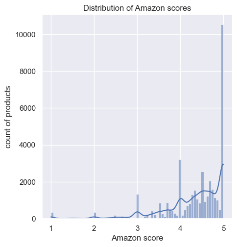

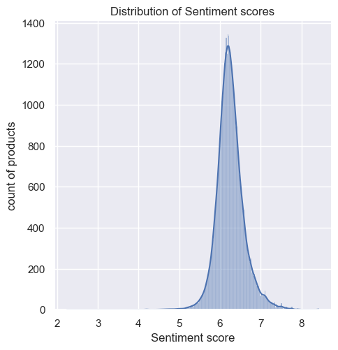

```python
sns.set(rc={"figure.dpi":100})
g1 = sns.displot(tempmeta.score, kde=True)
g1.set_axis_labels("Amazon score", "count of products")
g1.set(title="Distribution of Amazon scores")
#sns.displot(tempmeta.sentiment_score, kde=True)

g1 = sns.displot(tempmeta.sentiment_score, kde=True)
g1.set_axis_labels("Sentiment score", "count of products")
g1.set(title="Distribution of Sentiment scores")
```

```
[Text(0.5, 1.0, 'Sentiment scores vs Amazon score')]
```

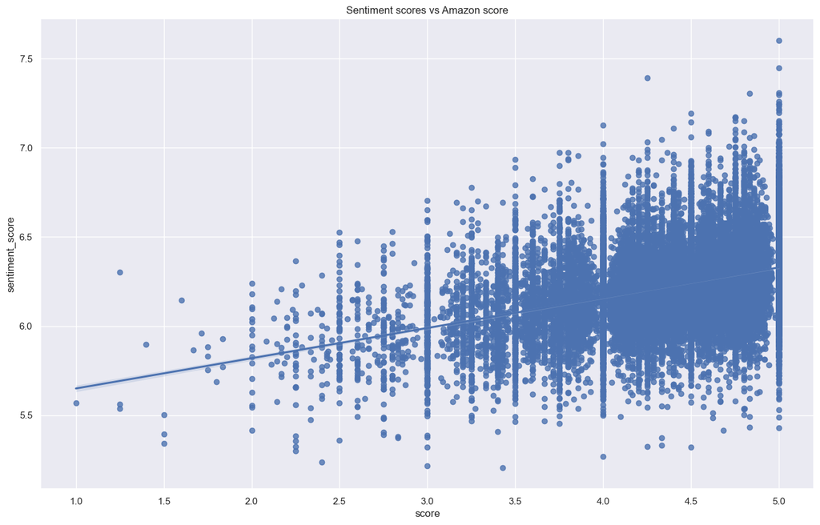

```python
v = food.asin.value_counts()
plotmeta = meta[meta.asin.isin(v.index[v.gt(3)])]
sns.set(rc={"figure.figsize":(16, 10)})
sns.regplot(data=plotmeta, x="score", y="sentiment_score").set(title="Sentiment scores vs Amazon score")
```

```
[Text(0.5, 1.0, 'Amazom score vs Sentiment Score - Mean plot')]
```

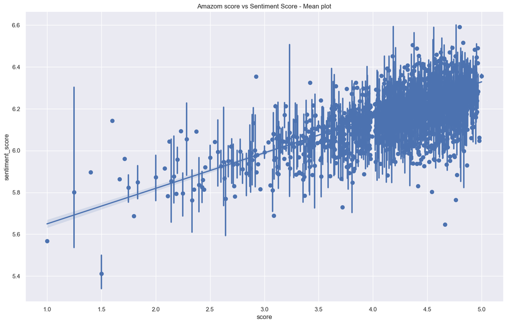

```python
v = food.asin.value_counts()
plotmeta = meta[meta.asin.isin(v.index[v.gt(3)])]
sns.set(rc={"figure.figsize":(16, 10)})
sns.regplot(data=plotmeta, x="score", y="sentiment_score",x_estimator=np.mean).set(title="Amazom score vs Sentiment Score - Mean plot")
```